# Analyze_ab_test_results_notebook

## Analyze A/B Test Results

- Introduction
- Part I - Probability
- Part II - A/B Test
- Part III - Regression

### Introduction

For this project, the analyst will be working to understand the results of an A/B test run by an e-commerce website. The company has developed a new web page in order to try and increase the number of users who "convert," meaning the number of users who decide to pay for the company's product. The goal is to work through this notebook to help the company understand if they should implement this new page, keep the old page, or perhaps run the experiment longer to make their decision.

#### Part I - Probability

```python
#Import all the needed libraries.
import pandas as pd
import numpy as np
import random
import matplotlib.pyplot as plt
%matplotlib inline
random.seed(42)
```

```python
#Read in the dataset.
df=pd.read_csv("ab_data.csv")
#Show the first five records of the dataset.
df.head()
```

|  | user_id | timestamp | group | landing_page | converted |
| --- | --- | --- | --- | --- | --- |
| 0 | 851104 | 2017-01-21 22:11:48.556739 | control | old_page | 0 |
| 1 | 804228 | 2017-01-12 08:01:45.159739 | control | old_page | 0 |
| 2 | 661590 | 2017-01-11 16:55:06.154213 | treatment | new_page | 0 |
| 3 | 853541 | 2017-01-08 18:28:03.143765 | treatment | new_page | 0 |
| 4 | 864975 | 2017-01-21 01:52:26.210827 | control | old_page | 1 |

```python
#Find the number of rows in the dataset.
df.shape[0]
```

```
294478
```

```python
#Find The number of unique users in the dataset.
df.user_id.nunique()
```

```
290584
```

```python
#Find the proportion of users converted.
df.converted.mean()
```

```
0.11965919355605512
```

```python
#Find the number of times the 'new_page' and 'treatment' don't line up.
df_1=(df.query('group == "treatment"')['landing_page'] == "old_page").sum()
df_2=(df.query('group == "control"')['landing_page'] == "new_page").sum()
print(df_1+df_2)
```

```
3893
```

```python
#Find information about the dataframe including non-null values to recognize missing values.
df.info()
```

```
<class 'pandas.core.frame.DataFrame'>
RangeIndex: 294478 entries, 0 to 294477
Data columns (total 5 columns):
user_id         294478 non-null int64
timestamp       294478 non-null object
group           294478 non-null object
landing_page    294478 non-null object
converted       294478 non-null int64
dtypes: int64(2), object(3)
memory usage: 11.2+ MB
```

For the rows where **treatment** is not aligned with **new_page** or **control** is not aligned with **old_page**, we cannot be sure if this row truly received the new or old page. To handle this, the analyst will remove rows where the landing_page and group columns don't match.

```python
#Get indexes for columns under these conditions.
indexNames = df[(df['group'] == 'treatment') & (df['landing_page'] == 'old_page') | (df['group'] == 'control') & (df['landing_page'] == 'new_page')].index
#Delete these row indexes from dataFrame.
df2=df.drop(indexNames)
```

```python
#Double Check all of the correct rows were removed.
df2[((df2['group'] == 'treatment') == (df2['landing_page'] == 'new_page')) == False].shape[0]
```

```
0
```

```python
#Find the number of unique 'user_id' in df2.
df2.user_id.nunique()
```

```
290584
```

```python
#Select duplicate rows.
dupl_df= df2[df2.user_id.duplicated()]
print(dupl_df)
```

```
      user_id                   timestamp      group landing_page  converted
2893   773192  2017-01-14 02:55:59.590927  treatment     new_page          0
```

```python
#Drop duplicate rows.
df2.drop_duplicates()
#Check if duplicate rows are removed.
sum(df2.duplicated())
```

```
0
```

```python
#Find the probability of an individual converting regardless of the page they receive.
df2.converted.mean()
```

```
0.11959667567149027
```

```python
#Find the probability of converting of an individual under the 'control' group.
(df2.query('group == "control"')['converted'] == True).mean()
```

```
0.1203863045004612
```

```python
#Find the probability of converting of an individual under the 'treatment' group.
(df2.query('group == "treatment"')['converted'] == True).mean()
```

```
0.11880724790277405
```

```python
#Find the probability that an individual received the new page.
(df2.landing_page == "new_page").mean()
```

```
0.5000636646764286
```

### Part II - A/B Test

Notice that because of the time stamp associated with each event, the analyst could technically run a hypothesis test continuously as each observation was observed.

However, then the hard question is do we stop as soon as one page is considered significantly better than another or does it need to happen consistently for a certain amount of time? How long do we run to render a decision that neither page is better than another?

`1.` The analyst will assume that the old page is better unless the new page proves to be definitely better at a Type I error rate of 5%.

PS: **$p_{old}$** and **$p_{new}$** are the converted rates for the old and new pages.

$$H_0: p_{new} - p_{old}<=0$$$$H_1: p_{new} - p_{old}>0$$

`2.` Assuming under the null hypothesis, $p_{new}$ and $p_{old}$ both have "true" success rates equal to the **converted** success rate regardless of page - that is $p_{new}$ and $p_{old}$ are equal. Furthermore, assuming they are equal to the **converted** rate in **ab_data.csv** regardless of the page.

The analyst wil use a sample size for each page equal to the ones in **ab_data.csv**. Then, will perform the sampling distribution for the difference in **converted** between the two pages over 10,000 iterations of calculating an estimate from the null.

```python
#Find the 'convert rate' for 'p new' under the null.
p_new= df2.query("converted == 1").user_id.nunique() / df2["user_id"].nunique()
p_new
```

```
0.11959708724499628
```

```python
#Find the 'convert rate' for 'p old' under the null.
p_old= df2.query("converted == 1").user_id.nunique() / df2["user_id"].nunique()
p_old
```

```
0.11959708724499628
```

```python
#Find 'n new'.
n_new= df2.query('landing_page == "new_page"').user_id.nunique()
n_new
```

```
145310
```

```python
#Find 'n old'.
n_old= df2.query('landing_page == "old_page"').user_id.nunique()
n_old
```

```
145274
```

```python
#Simulate 'n new' transactions with a convert rate of 'p new' under the null.
#Store these 'n new' 1's and 0's in 'new_page_converted'.
new_page_converted= np.random.choice([0,1], n_new, p_new).mean()
new_page_converted
```

```
0.5027320900144518
```

```python
#Simulate 'n old' transactions with a convert rate of 'p old' under the null.
#Store these 'n old' 1's and 0's in 'old_page_converted'.
old_page_converted= np.random.choice([0,1], n_old, p_old).mean()
old_page_converted
```

```
0.5003648278425595
```

```python
#Find 'p new'-'p old' for the simulated values above.
diff=new_page_converted-old_page_converted
diff
```

```
0.002367262171892315
```

```python
#Create a sampling distribution for the difference with boostrapping.
diffs = []
size = df2.shape[0]
for _ in range(10000):
    b_samp = df.sample(size, replace=True)
    new_page_converted= np.random.choice([0,1], n_new, p_new).mean()
    old_page_converted= np.random.choice([0,1], n_old, p_old).mean()
    diffs.append(new_page_converted-old_page_converted)
```

```python
#Convert to numpy array.
p_diffs= np.array(diffs)
```

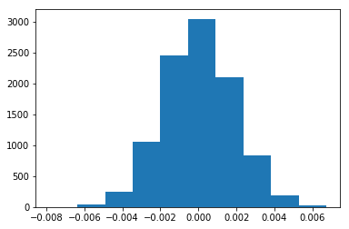

```python
#Plot sampling distribution.
plt.hist(p_diffs);
```

The plot looks like what the analyst expected! It is normally distributed. In fact, based on the central limit theorem, the sampling distribution of the mean will be normally distributed with a large sample size.

```python
#Compute observed differences in conversion rate.
control_df=(df2.query('group == "control"')['converted'] == True).mean()
treatment_df=(df2.query('group == "treatment"')['converted'] == True).mean()
obs_diff=treatment_df-control_df

#Display observed difference.
obs_diff
```

```
-0.0015790565976871451
```

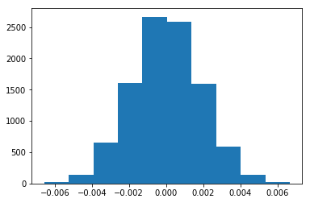

```python
#Simulate distribution under the null hypothesis.
null_vals = np.random.normal(0, p_diffs.std(), p_diffs.size)

#Plot the null distribution.
plt.hist(null_vals);
```

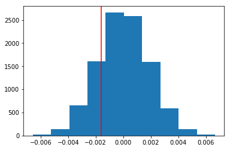

```python
#Plot observed statistic with the null distibution.
plt.hist(null_vals);
plt.axvline(obs_diff, c='red')
```

```python
#Compute p-value.
(null_vals > obs_diff).mean()
```

```
0.8013
```

**The analyst has just computed the p-value. Which is the probability of getting your statistics or a more extrem value if the null is true.**

**When the p-value is large, we have evidence that our statistics was likely to come from the null hypothesis. Therefore, we do not have evidence to reject the null.**

**By comparing our p-value of 0.80 to our Type 1 error threshold of 0.05, we failed to reject the null hypothesis and we have no evidence for the alternative. In other words, we do not have evidence that the new web page increase the number of users who convert.**

We could also use a built-in to achieve similar results. Though using the built-in might be easier to code, the above portions are a walkthrough of the ideas that are critical to correctly thinking about statistical significance.

```python
#Import the needed library.
import statsmodels.api as sm

#Calculate the number of conversions for each page.
convert_old = df2.query('group == "control" and converted == True').user_id.nunique()
convert_new = df2.query('group == "treatment" and converted == True').user_id.nunique()
#Calculate the number of individuals who received each page.
n_old = df2.query('landing_page == "old_page"').user_id.nunique()
n_new = df2.query('landing_page == "new_page"').user_id.nunique()
```

```python
#Calculate z-test and p-value.
sm.stats.proportions_ztest([convert_new, convert_old], nobs=[n_new, n_old], alternative= 'larger')
```

```
(-1.3109241984234394, 0.9050583127590245)
```

**By comparing our p-value of 0.90 resulted from the z-test to our Type 1 error threshold of 0.05, we failed to reject the null hypothesis and we have no evidence for the alternative. In other words, we do not have evidence that the new web page increase the number of users who convert. This agrees with the previous findings where the p-value was 0.80.**

### Part III - A regression approach

The result the analyst acheived in the previous A/B test can also be acheived by performing regression.  
**In this case the analyst will perform Logistic Regression as the response variable is categorical variable.**

The goal is to use **statsmodels** to fit the model to see if there is a significant difference in conversion based on which page a customer receives.

```python
#Import the needed library.
import statsmodels.api as sm

#Add the intercept, and create the dummy variables.
df2['intercept'] = 1
df2['ab_page'] = pd.get_dummies(df2['group'])['treatment']
#show the first six records of the dataset.
df2.head(6)
```

|  | user_id | timestamp | group | landing_page | converted | intercept | ab_page |
| --- | --- | --- | --- | --- | --- | --- | --- |
| 0 | 851104 | 2017-01-21 22:11:48.556739 | control | old_page | 0 | 1 | 0 |
| 1 | 804228 | 2017-01-12 08:01:45.159739 | control | old_page | 0 | 1 | 0 |
| 2 | 661590 | 2017-01-11 16:55:06.154213 | treatment | new_page | 0 | 1 | 1 |
| 3 | 853541 | 2017-01-08 18:28:03.143765 | treatment | new_page | 0 | 1 | 1 |
| 4 | 864975 | 2017-01-21 01:52:26.210827 | control | old_page | 1 | 1 | 0 |
| 5 | 936923 | 2017-01-10 15:20:49.083499 | control | old_page | 0 | 1 | 0 |

```python
#Fit the model.
log_mod = sm.Logit(df2['converted'], df2[['intercept', 'ab_page']])
results = log_mod.fit()
```

```
Optimization terminated successfully.
         Current function value: 0.366118
         Iterations 6
```

```python
#Provide summary.
results.summary()
```

Logit Regression Results

| Dep. Variable: | converted | No. Observations: | 290585 |
| --- | --- | --- | --- |
| Model: | Logit | Df Residuals: | 290583 |
| Method: | MLE | Df Model: | 1 |
| Date: | Mon, 13 May 2019 | Pseudo R-squ.: | 8.085e-06 |
| Time: | 15:49:23 | Log-Likelihood: | -1.0639e+05 |
| converged: | True | LL-Null: | -1.0639e+05 |
|  |  | LLR p-value: | 0.1897 |

|  | coef | std err | z | P>\|z\| | [0.025 | 0.975] |
| --- | --- | --- | --- | --- | --- | --- |
| intercept | -1.9888 | 0.008 | -246.669 | 0.000 | -2.005 | -1.973 |
| ab_page | -0.0150 | 0.011 | -1.312 | 0.190 | -0.037 | 0.007 |

**The p-value associated with ab_page is 0.190. The value differs from the one we found in Part II because the tested hypotheses here are as follow**

$$H_0: p_{new} = p_{old}$$$$H_1: p_{new} \neq p_{old}$$

**In other words, Part III is a two-tailed test while Part II is a one-tail test.**

One of the things that might influence whether or not an individual converts is the country the user lives in. It is a good idea to consider other factors to add into the regression model because this will provide more precise results.

```python
#Read the dataset.
countries_df = pd.read_csv('./countries.csv')
#show the first five records of the dataset.
countries_df.head()
```

|  | user_id | country |
| --- | --- | --- |
| 0 | 834778 | UK |
| 1 | 928468 | US |
| 2 | 822059 | UK |
| 3 | 711597 | UK |
| 4 | 710616 | UK |

```python
#Merge the datasets on 'user_id'.
df_new = countries_df.set_index('user_id').join(df2.set_index('user_id'), how='inner')
#show the first five records of the dataset.
df_new.head()
```

| user_id | country | timestamp | group | landing_page | converted | intercept | ab_page |
| --- | --- | --- | --- | --- | --- | --- | --- |
| 630000 | US | 2017-01-19 06:26:06.548941 | treatment | new_page | 0 | 1 | 1 |
| 630001 | US | 2017-01-16 03:16:42.560309 | treatment | new_page | 1 | 1 | 1 |
| 630002 | US | 2017-01-19 19:20:56.438330 | control | old_page | 0 | 1 | 0 |
| 630003 | US | 2017-01-12 10:09:31.510471 | treatment | new_page | 0 | 1 | 1 |
| 630004 | US | 2017-01-18 20:23:58.824994 | treatment | new_page | 0 | 1 | 1 |

```python
#Find unique values under country.
df_new.country.unique()
```

```
array(['US', 'UK', 'CA'], dtype=object)
```

```python
#Add the intercept, and create the dummy variables.
df_new['intercept'] = 1
df_new[['US', 'UK', 'CA']] = pd.get_dummies(df_new['country'])
df_new= df_new.drop('CA', axis=1)
#Show the first six records of the dataset.
df_new.head(6)
```

| user_id | country | timestamp | group | landing_page | converted | intercept | ab_page | US | UK |
| --- | --- | --- | --- | --- | --- | --- | --- | --- | --- |
| 630000 | US | 2017-01-19 06:26:06.548941 | treatment | new_page | 0 | 1 | 1 | 0 | 0 |
| 630001 | US | 2017-01-16 03:16:42.560309 | treatment | new_page | 1 | 1 | 1 | 0 | 0 |
| 630002 | US | 2017-01-19 19:20:56.438330 | control | old_page | 0 | 1 | 0 | 0 | 0 |
| 630003 | US | 2017-01-12 10:09:31.510471 | treatment | new_page | 0 | 1 | 1 | 0 | 0 |
| 630004 | US | 2017-01-18 20:23:58.824994 | treatment | new_page | 0 | 1 | 1 | 0 | 0 |
| 630005 | US | 2017-01-17 21:22:25.940766 | treatment | new_page | 1 | 1 | 1 | 0 | 0 |

```python
#Fit the model and provide summary.
log_mod_2 = sm.Logit(df_new['converted'], df_new[['intercept', 'ab_page', 'US', 'UK']])
results = log_mod_2.fit()
results.summary()
```

```
Optimization terminated successfully.
         Current function value: 0.366112
         Iterations 6
```

Logit Regression Results

| Dep. Variable: | converted | No. Observations: | 290585 |
| --- | --- | --- | --- |
| Model: | Logit | Df Residuals: | 290581 |
| Method: | MLE | Df Model: | 3 |
| Date: | Mon, 13 May 2019 | Pseudo R-squ.: | 2.324e-05 |
| Time: | 15:51:59 | Log-Likelihood: | -1.0639e+05 |
| converged: | True | LL-Null: | -1.0639e+05 |
|  |  | LLR p-value: | 0.1758 |

|  | coef | std err | z | P>\|z\| | [0.025 | 0.975] |
| --- | --- | --- | --- | --- | --- | --- |
| intercept | -1.9893 | 0.009 | -223.763 | 0.000 | -2.007 | -1.972 |
| ab_page | -0.0150 | 0.011 | -1.308 | 0.191 | -0.037 | 0.007 |
| US | -0.0408 | 0.027 | -1.516 | 0.130 | -0.093 | 0.012 |
| UK | 0.0099 | 0.013 | 0.744 | 0.457 | -0.016 | 0.036 |

```python
#Exponentiate.
np.exp(results.params)
```

```
intercept    0.136795
ab_page      0.985160
US           0.960068
UK           1.009938
dtype: float64
```

```python
#Find reciprocal.
1/np.exp(results.params)
```

```
intercept    7.310219
ab_page      1.015064
US           1.041593
UK           0.990160
dtype: float64
```

**Interpreting results:**

The p-value for all the factors are above 5%. Thus, it appears that country has no impact on conversion.

Though the analyst has now looked at the individual factors of country and page on conversion, we would now like to look at an interaction between page and country to see if there significant effects on conversion.

```python
#Create the new columns.
df_new['US_ab_page']= df_new['ab_page']*df_new['US']
df_new['UK_ab_page']= df_new['ab_page']*df_new['UK']
#Show the records.
df_new.head()
```

| user_id | country | timestamp | group | landing_page | converted | intercept | ab_page | US | UK | US_ab_page | UK_ab_page |
| --- | --- | --- | --- | --- | --- | --- | --- | --- | --- | --- | --- |
| 630000 | US | 2017-01-19 06:26:06.548941 | treatment | new_page | 0 | 1 | 1 | 0 | 0 | 0 | 0 |
| 630001 | US | 2017-01-16 03:16:42.560309 | treatment | new_page | 1 | 1 | 1 | 0 | 0 | 0 | 0 |
| 630002 | US | 2017-01-19 19:20:56.438330 | control | old_page | 0 | 1 | 0 | 0 | 0 | 0 | 0 |
| 630003 | US | 2017-01-12 10:09:31.510471 | treatment | new_page | 0 | 1 | 1 | 0 | 0 | 0 | 0 |
| 630004 | US | 2017-01-18 20:23:58.824994 | treatment | new_page | 0 | 1 | 1 | 0 | 0 | 0 | 0 |

```python
#Fit the new model and show summary.
log_mod_3 = sm.Logit(df_new['converted'], df_new[['intercept', 'ab_page', 'US', 'UK', 'US_ab_page', 'UK_ab_page']])
results = log_mod_3.fit()
results.summary()
```

```
Optimization terminated successfully.
         Current function value: 0.366108
         Iterations 6
```

Logit Regression Results

| Dep. Variable: | converted | No. Observations: | 290585 |
| --- | --- | --- | --- |
| Model: | Logit | Df Residuals: | 290579 |
| Method: | MLE | Df Model: | 5 |
| Date: | Mon, 13 May 2019 | Pseudo R-squ.: | 3.483e-05 |
| Time: | 15:56:13 | Log-Likelihood: | -1.0639e+05 |
| converged: | True | LL-Null: | -1.0639e+05 |
|  |  | LLR p-value: | 0.1918 |

|  | coef | std err | z | P>\|z\| | [0.025 | 0.975] |
| --- | --- | --- | --- | --- | --- | --- |
| intercept | -1.9865 | 0.010 | -206.344 | 0.000 | -2.005 | -1.968 |
| ab_page | -0.0206 | 0.014 | -1.506 | 0.132 | -0.047 | 0.006 |
| US | -0.0175 | 0.038 | -0.465 | 0.642 | -0.091 | 0.056 |
| UK | -0.0057 | 0.019 | -0.306 | 0.760 | -0.043 | 0.031 |
| US_ab_page | -0.0469 | 0.054 | -0.872 | 0.383 | -0.152 | 0.059 |
| UK_ab_page | 0.0314 | 0.027 | 1.181 | 0.238 | -0.021 | 0.084 |

**Interpreting results:**

The p-value for all the factors are above 5%. Thus, it appears that there is no interaction between page and country and they do not have any significant effects on conversion.

To determine if the logistic regression model is doing well at predicting the correct labels, the analyst will use the accuracy measure.

```python
#Read in the necessary libraries.
from sklearn.linear_model import LogisticRegression
from sklearn.metrics import accuracy_score
from sklearn.model_selection import train_test_split
```

```python
#Define the needed data.
x = df_new[[ 'ab_page', 'US', 'UK', 'US_ab_page', 'UK_ab_page']]
y = df_new['converted']
#Split data into training and testing data.
x_train, x_test, y_train, y_test = train_test_split(
          x, y, test_size=0.20, random_state=0)
```

```python
#Fit the model and calculate accuracy score.
log_mod = LogisticRegression(solver='lbfgs')
log_mod.fit(x_train, y_train)
preds = log_mod.predict(x_test)
accuracy_score(y_test, preds)
```

```
0.8811363284409037
```

## Conclusions

As a reminder, the company has developed a new web page in order to try and increase the number of users who "convert," meaning the number of users who decide to pay for the company's product. The goal was to work through this notebook to help the company understand if they should implement this new page, keep the old page, or perhaps run the experiment longer to make their decision.

Based on the findings, we failed to reject the null hypothesis and we have no evidence for the alternative. In other words, we do not have evidence that the new web page increase the number of users who convert.